# Statistical learning: Advanced - M2 TIDE

```python
# Pivot table on Status Chacking Acc variable
table = pd.pivot_table(data, values = 'Customer_ID', index = ['Status_Checking_Acc'], columns=['Default_On_Payment'],  aggfunc='count')
table
```

| Default_On_Payment Status_Checking_Acc | 0 | 1 |
| --- | --- | --- |
| 10.000 and more | 245 | 70 |
| < 0 USD | 695 | 675 |
| between 0 and 9.999 | 825 | 520 |
| no checking account | 1740 | 230 |

Defaults occur most often on accounts with negative funds or with amounts between 0 and 10,000 USD

```python
var_qualitatives = ['Status_Checking_Acc', 'Credit_History', 'Purposre_Credit_Taken', 'Savings_Acc', 'Years_At_Present_Employment',
                   'Marital_Status_Gender', 'Other_Debtors_Guarantors', 'Property', 'Other_Inst_Plans ', 'Housing', 'Job', 'Telephone', 'Foreign_Worker']
```

```python
for elem in var_qualitatives:
    globals()[f"table_{elem}"] = pd.pivot_table(data, values = 'Customer_ID', index = [elem], columns=['Default_On_Payment'],  aggfunc='count')
```

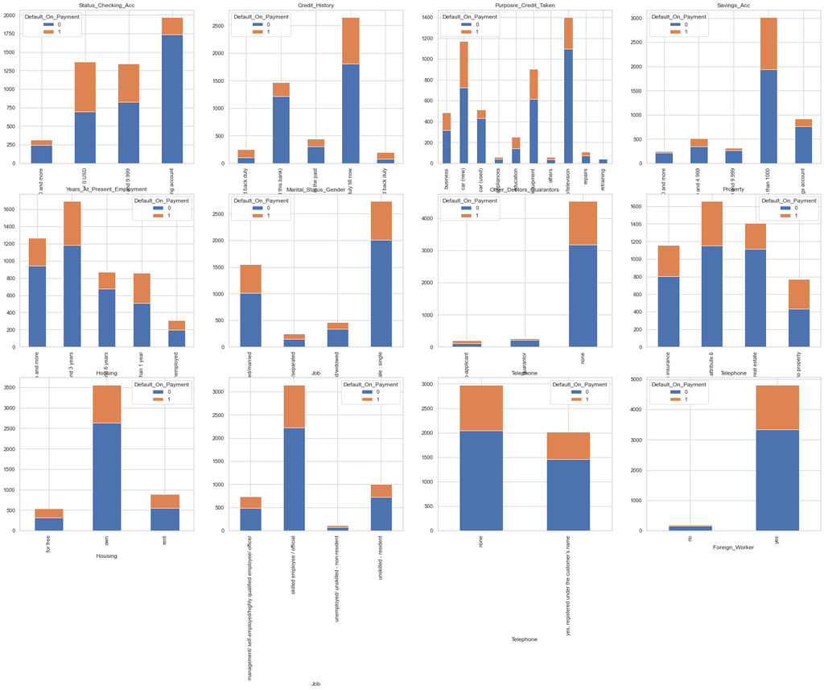

```python
plt.figure()

fig, axes = plt.subplots(3, 4, figsize=(30, 20))

table_Status_Checking_Acc.plot(kind="bar",stacked=True, ax = axes[0,0])
axes[0,0].title.set_text(var_qualitatives[0])

table_Credit_History.plot(kind="bar",stacked=True, ax = axes[0,1])
axes[0,1].title.set_text(var_qualitatives[1])

table_Purposre_Credit_Taken.plot(kind="bar",stacked=True, ax = axes[0,2])
axes[0,2].title.set_text(var_qualitatives[2])

table_Savings_Acc.plot(kind="bar",stacked=True, ax = axes[0,3])
axes[0,3].title.set_text(var_qualitatives[3])

table_Years_At_Present_Employment.plot(kind="bar",stacked=True, ax = axes[1,0])
axes[1,0].title.set_text(var_qualitatives[4])

table_Marital_Status_Gender.plot(kind="bar",stacked=True, ax = axes[1,1])
axes[1,1].title.set_text(var_qualitatives[5])

table_Other_Debtors_Guarantors.plot(kind="bar",stacked=True, ax = axes[1,2])
axes[1,2].title.set_text(var_qualitatives[6])

table_Property.plot(kind="bar",stacked=True, ax = axes[1,3])
axes[1,3].title.set_text(var_qualitatives[7])

table_Housing.plot(kind="bar",stacked=True, ax = axes[2,0])
axes[2,0].title.set_text(var_qualitatives[9])

table_Job.plot(kind="bar",stacked=True, ax = axes[2,1])
axes[2,1].title.set_text(var_qualitatives[10])

table_Telephone.plot(kind="bar",stacked=True, ax = axes[2,2])
axes[2,2].title.set_text(var_qualitatives[11])

table_Foreign_Worker.plot(kind="bar",stacked=True, ax = axes[2,3])
axes[2,3].title.set_text(var_qualitatives[11])

plt.show()
```

For each variable, a category emerges that has the most payment defaults. In most cases, this category is proportional to the number of observations. But for the featire Status_checking_acc, the category '< 0 USD' has more defaults even though it is not in the majority

```python
table_Foreign_Worker['% de 0'] = table_Foreign_Worker[0]/(table_Foreign_Worker[0]+table_Foreign_Worker[1])
table_Foreign_Worker['% de 1'] = table_Foreign_Worker[1]/(table_Foreign_Worker[0]+table_Foreign_Worker[1])
```

```python
table_Foreign_Worker
```

| Default_On_Payment Foreign_Worker | 0 | 1 | % de 0 | % de 1 |
| --- | --- | --- | --- | --- |
| no | 165 | 20 | 0.891892 | 0.108108 |
| yes | 3340 | 1475 | 0.693666 | 0.306334 |

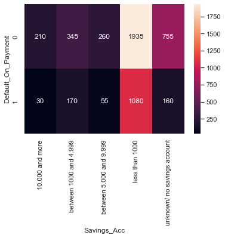

```python
sns.heatmap(pd.crosstab(data['Default_On_Payment'], data['Savings_Acc']), annot=True, fmt='d');
```

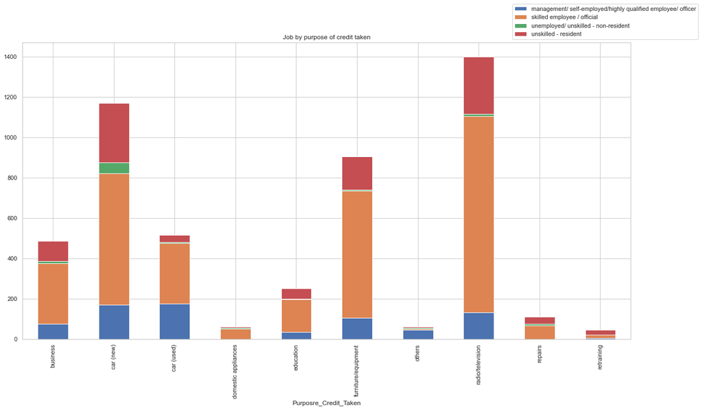

```python
# Job and purpose
table = pd.pivot_table(data, values = 'Customer_ID', index = ['Purposre_Credit_Taken'], columns=['Job'],  aggfunc='count')

table.plot(kind="bar",stacked=True,figsize=(20,10))
plt.legend(loc="lower left",bbox_to_anchor=(0.8,1.0))
plt.title('Job by purpose of credit taken')
plt.show()
```

```python
# let's try to create two separated variables sex and status
data.Marital_Status_Gender.value_counts()
```

```
male : single                         2740
female: divorced/separated/married    1550
male : married/widowed                 460
male : divorced/separated              250
Name: Marital_Status_Gender, dtype: int64
```

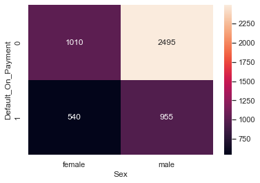

```python
def sex(x):
    if x['Marital_Status_Gender'] == 'female: divorced/separated/married':
        return 'female'
    else:
        return 'male'

data.insert(10, 'Sex', data.apply(sex, axis = 1))

sns.heatmap(pd.crosstab(data['Default_On_Payment'], data['Sex']), annot=True, fmt='d');
```

```python
var_qualitatives.append('Sex')
```

The values of status cannot be grouped together. Indeed, women have only one category that groups everything. We will therefore not work on the status

# Modelisation

```python
data.head(2)
```

|  | Customer_ID | Status_Checking_Acc | Duration_in_Months | Credit_History | Purposre_Credit_Taken | Credit_Amount | Savings_Acc | Years_At_Present_Employment | Inst_Rt_Income | Marital_Status_Gender | Sex | Other_Debtors_Guarantors | Current_Address_Yrs | Property | Age | Other_Inst_Plans | Housing | Num_CC | Job | Dependents | Telephone | Foreign_Worker | Default_On_Payment |
| --- | --- | --- | --- | --- | --- | --- | --- | --- | --- | --- | --- | --- | --- | --- | --- | --- | --- | --- | --- | --- | --- | --- | --- |
| 0 | 100001 | < 0 USD | 6 | critical account/other credits existing(not at... | radio/television | 1169 | unknown/ no savings account | 7 years and more | 4 | male : single | male | none | 4 | real estate | 67 | none | own | 2 | skilled employee / official | 1 | yes, registered under the customer’s name | yes | 0 |
| 1 | 100002 | between 0 and 9.999 | 48 | existing credits paid back duly till now | radio/television | 5951 | less than 1000 | between 1 and 3 years | 2 | female: divorced/separated/married | female | none | 2 | real estate | 22 | none | own | 1 | skilled employee / official | 1 | none | yes | 0 |

```python
# Feature Scaling

# let's use one-hot encoding with get_dummies
df_dummies = pd.get_dummies(data, columns=var_qualitatives)

for elem in var_continues :
    df_dummies[elem] = StandardScaler().fit_transform(df_dummies[elem].values.reshape(-1,1))

df_dummies.drop('Customer_ID', axis = 1, inplace = True)
df_dummies['Default_On_Payment'] = data['Default_On_Payment']
```

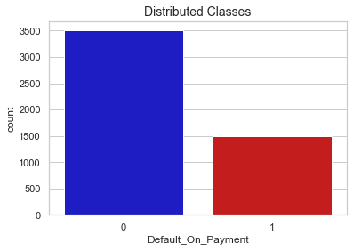

```
Distribution of the Classes in the subsample dataset
0    0.701
1    0.299
Name: Default_On_Payment, dtype: float64
Target 0 : 3505
Target 1 : 1495
```

```python
colors = ["#0101DF", "#DF0101"]
sns.countplot('Default_On_Payment', data=df_dummies, palette=colors)
plt.title('Distributed Classes', fontsize=14)
plt.show()

print('Distribution of the Classes in the subsample dataset')
print(df_dummies['Default_On_Payment'].value_counts()/len(df_dummies))
print("Target 0 :", df_dummies[df_dummies['Default_On_Payment'] == 0].shape[0])
print("Target 1 :", df_dummies[df_dummies['Default_On_Payment'] == 1].shape[0])
```

**Manage imbalances dataset**

The data is imbalanced (less than 30% of the data is defaulted). There are four main methods to manage imbalanced:

- **Undersampling** : random undersample data (we don't have enough data to use this method)
- **Oversampling** : oversample data with many techniques
- **Sample weighting**: we play on the cost function to penalize when it makes an error in the minority class
- **Stratify** : use of stratify during the train test split

```python
df_dummies.head(2)
```

|  | Duration_in_Months | Credit_Amount | Inst_Rt_Income | Current_Address_Yrs | Age | Num_CC | Dependents | Default_On_Payment | Status_Checking_Acc_10.000 and more | Status_Checking_Acc_< 0 USD | Status_Checking_Acc_between 0 and 9.999 | Status_Checking_Acc_no checking account | Credit_History_all credits at this bank paid back duly | Credit_History_critical account/other credits existing(not at this bank) | Credit_History_delay in paying off in the past | Credit_History_existing credits paid back duly till now | Credit_History_no credits taken/all credits paid back duly | Purposre_Credit_Taken_business | Purposre_Credit_Taken_car (new) | Purposre_Credit_Taken_car (used) | Purposre_Credit_Taken_domestic appliances | Purposre_Credit_Taken_education | Purposre_Credit_Taken_furniture/equipment | Purposre_Credit_Taken_others | Purposre_Credit_Taken_radio/television | Purposre_Credit_Taken_repairs | Purposre_Credit_Taken_retraining | Savings_Acc_10.000 and more | Savings_Acc_between 1000 and 4.999 | … |
| --- | --- | --- | --- | --- | --- | --- | --- | --- | --- | --- | --- | --- | --- | --- | --- | --- | --- | --- | --- | --- | --- | --- | --- | --- | --- | --- | --- | --- | --- | --- |
| 0 | -1.236478 | -0.745131 | 0.918477 | 1.046987 | 2.766456 | 1.027079 | -0.42829 | 0 | 0 | 1 | 0 | 0 | 0 | 1 | 0 | 0 | 0 | 0 | 0 | 0 | 0 | 0 | 0 | 0 | 1 | 0 | 0 | 0 | 0 | … |
| 1 | 2.248194 | 0.949817 | -0.870183 | -0.765977 | -1.191404 | -0.704926 | -0.42829 | 0 | 0 | 0 | 1 | 0 | 0 | 0 | 0 | 1 | 0 | 0 | 0 | 0 | 0 | 0 | 0 | 0 | 1 | 0 | 0 | 0 | 0 | … |

```python
# Use of the stratified sample concept: to have the same distribution in the 2 data sets
from sklearn.model_selection import train_test_split

X_train, X_test, y_train, y_test = train_test_split(df_dummies.drop('Default_On_Payment', axis = 1), df_dummies['Default_On_Payment'],
                                                    test_size=0.3, stratify=df_dummies['Default_On_Payment'])
```

```python
from sklearn.ensemble import RandomForestClassifier
from sklearn.model_selection import cross_val_score
from sklearn.metrics import classification_report

# Let's implement simple Random Forest classifier
RandomForestClassifier().fit(X_train, y_train)
training_score = cross_val_score(RandomForestClassifier(), X_train, y_train, cv=5)
print("Random Forest Classifier: has a training score of", round(training_score.mean(), 4) * 100, "% accuracy score")
ypred = RandomForestClassifier().fit(X_train, y_train).predict(X_test)
print(classification_report(ypred, y_test))
```

```
Random Forest Classifier: has a training score of 98.86 % accuracy score
              precision    recall  f1-score   support

           0       1.00      1.00      1.00      1052
           1       1.00      1.00      1.00       448

    accuracy                           1.00      1500
   macro avg       1.00      1.00      1.00      1500
weighted avg       1.00      1.00      1.00      1500
```

The results are very good, we don't need to use the other methods mentioned (Oversampling, Undersampling, Sample weighting)

```python
import time
import numpy as np

forest = RandomForestClassifier().fit(X_train, y_train)

start_time = time.time()
importances = forest.feature_importances_
std = np.std([tree.feature_importances_ for tree in forest.estimators_], axis=0)
elapsed_time = time.time() - start_time

print(f"Elapsed time to compute the importances: {elapsed_time:.3f} seconds")
```

```
Elapsed time to compute the importances: 0.073 seconds
```

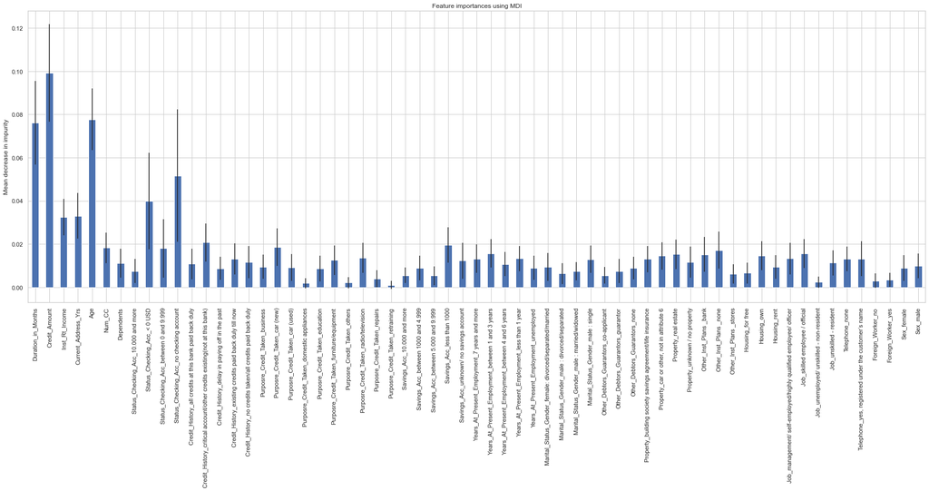

```python
import pandas as pd

forest_importances = pd.Series(importances, index=df_dummies.drop('Default_On_Payment', axis = 1).columns)

plt.figure(figsize=(30,10))
forest_importances.plot.bar(yerr=std)
plt.title("Feature importances using MDI")
plt.ylabel("Mean decrease in impurity")
fig.tight_layout()
```

Credit Amount, Duration in months, Age and No chacking account status appear to be the most correlated variables with our target variable

# Part 2 : European companies Database

```python
data = pd.read_excel('C:/Users/Yalap/Documents/Cours/M2 TIDE/S2/Apprentissage statistique avancé/Projet/data_orig.xlsx', sheet_name = "all")
```

This second dataset is very atypical : we have 489 features for 14 759 observations! We don't have a lot of information on their meaning but we tried to analyze some to understand the whole dataset. There are many missing values, we tried to deal with by :

1. removing columns with 20% of missing values or plus
2. removing lines with the same problem
3. impute the remaining missing values with the mean of the column
4. impute the remaning missing values by using a KNN approach

```python
print("Dim :", data.shape)
data.head()
```

```
Dim : (14759, 489)
```

|  | mark | pavitt | age | country | region | sector | pav | years | core_p | turnov | flop | group | group_position | acquire | acquired | affiliate | foreign_affiliate | first_share | first_share_type | first_share_naz | a16_2 | a18_2 | a19_2 | a16_3 | a18_3 | a19_3 | a16_4 | family | ceo_type | … |
| --- | --- | --- | --- | --- | --- | --- | --- | --- | --- | --- | --- | --- | --- | --- | --- | --- | --- | --- | --- | --- | --- | --- | --- | --- | --- | --- | --- | --- | --- | --- |
| 0 | 40 | Specialized industries | More than 20 yrs | AUT | 122 | 11 | 2 | 3 | 100.0 | 7.0 | 2.0 | 2 | 2.0 | 2.0 | 4 | 2.0 | 6.0 | 100.0 | 6.0 | 2.0 | 1.000000e+10 | 1.000000e+10 | 1.000000e+10 | 1.000000e+10 | 1.000000e+10 | 1.000000e+10 | 1.000000e+10 | 1.0 | 3.0 | … |
| 1 | 41 | Traditional industries | More than 20 yrs | AUT | 122 | 4 | 1 | 3 | 100.0 | 6.0 | 1.0 | 3 | NaN | 4.0 | 4 | 2.0 | 2.0 | 100.0 | 2.0 | 1.0 | 1.000000e+10 | 1.000000e+10 | 1.000000e+10 | 1.000000e+10 | 1.000000e+10 | 1.000000e+10 | 1.000000e+10 | 1.0 | 1.0 | … |
| 2 | 42 | Economies of scale industries | More than 20 yrs | AUT | 116 | 10 | 3 | 3 | 100.0 | 6.0 | 2.0 | 2 | 1.0 | 2.0 | 4 | 4.0 | NaN | 100.0 | NaN | 1.0 | NaN | NaN | NaN | NaN | NaN | NaN | NaN | 1.0 | 1.0 | … |
| 3 | 43 | Traditional industries | Between 20 and 6 yrs | AUT | 122 | 1 | 1 | 2 | 100.0 | 3.0 | 2.0 | 3 | NaN | 4.0 | 4 | 4.0 | NaN | 38.0 | 1.0 | 1.0 | 3.800000e+01 | 1.000000e+00 | 1.000000e+00 | 2.400000e+01 | 1.000000e+00 | 1.000000e+00 | 1.000000e+10 | 1.0 | 1.0 | … |
| 4 | 44 | Traditional industries | More than 20 yrs | AUT | 122 | 4 | 1 | 3 | 95.0 | 2.0 | 2.0 | 3 | NaN | 4.0 | 4 | 4.0 | NaN | 100.0 | 1.0 | 1.0 | 1.000000e+10 | 1.000000e+10 | 1.000000e+10 | 1.000000e+10 | 1.000000e+10 | 1.000000e+10 | 1.000000e+10 | 1.0 | 1.0 | … |

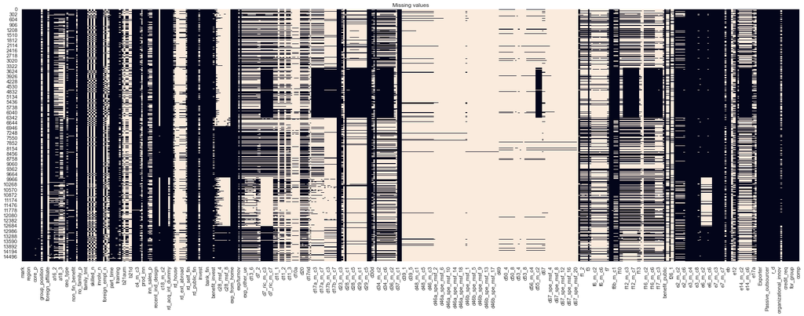

```python
# Visualization of the missing values in the dataset

plt.figure(figsize=(30,10))
sns.heatmap(data.isna(), cbar=False)
plt.title('Missing values')
plt.show()
```

### Checking missing values in columns

we calculate the proportion of missing values in all columns and first deleted variables with 80% of missing values, then 50%, to finally delete columns with 20% of missing values as we preferred deleting columns than lines of observation. We don't know the meaning of most of the features and we still have 166 variables in our dataset. It was not easy to decide to delete 323 features

```python
# % missing values per column
table_null = (data.isnull().sum())/(data.shape[0])
table_null = pd.DataFrame(table_null).reset_index()
table_null.columns = ['Variable', '% de valeur manquante']
table_null
```

|  | Variable | % de valeur manquante |
| --- | --- | --- |
| 0 | mark | 0.0 |
| 1 | pavitt | 0.0 |
| 2 | age | 0.0 |
| 3 | country | 0.0 |
| 4 | region | 0.0 |
| ... | ... | ... |
| 484 | for_group | 0.0 |
| 485 | decentr_manag | 0.0 |
| 486 | bonus.1 | 0.0 |
| 487 | qual_cert | 0.0 |
| 488 | comp | 0.0 |

489 rows × 2 columns

```python
liste_var = table_null[table_null['% de valeur manquante'] >= 0.2]['Variable'].values
# number of variables that will be removed
print(len(liste_var))
liste_var
```

```
323
```

```
array(['group_position', 'foreign_affiliate', 'a16_2', 'a18_2', 'a19_2',
       'a16_3', 'a18_3', 'a19_3', 'a16_4', 'ceo_type', 'bonus', 'white_p',
       'white_n', 'skilled_p', 'skilled_n', 'unskilled_p', 'unskilled_n',
       'foreign_empl_p', 'foreign_empl_n', 'b9_1', 'b9_2',
       'training_type', 'b21rid', 'b21aum', 'b21a', 'b21b', 'b21c',
       'b21d', 'c13aperc', 'org_inn', 'inn_sales_p', 'c16',
       'recent_copyright', 'rd_p', 'rd_house', 'rd_group',
       'rd_group_abroad', 'rd_ext', 'rd_ext_abroad', 'c23_1', 'c23_2',
       'rd_financed_as_invest', 'benefit_rd', 'c28_msf_2', 'c28_msf_3',
       'c28_msf_4', 'c28_msf_5', 'c28_msf_6', 'c28_msf_7', 'c28_msf_8',
       'c28_msf_9', 'c28_msf_10', 'exp/turnov', 'exp_richness',
       'exp_15ue', 'exp_other_ue', 'exp_other_euro_no_ue', 'd13_4',
       'd13_5', 'd13_6', 'd13_7', 'd13_8', 'd7_1', 'd7_2', 'd7_3',
       'd7_ric_m_c1', 'd7_ric_m_c2', 'd7_ric_m_c3', 'd7_ric_m_c4',
       'd7_ric_m_c5', 'd7_ric_m_c6', 'd7_ric_m_c7', 'd7_ric_m_c8', 'd9_1',
       'd10_1', 'd11_1', 'd12_1', 'd9_2', 'd10_2', 'd11_2', 'd12_2',
       'd9_3', 'd10_3', 'd11_3', 'd12_3', 'd9a_pre', 'd9a', 'd10a',
       'd11a', 'd12a', 'd16', 'd20', 'd20a', 'benefit_export', 'pred17',
       'd17rid', 'd17aum', 'd17a_m_c1', 'd17a_m_c2', 'd17a_m_c3',
       'd17a_m_c4', 'd17a_m_c5', 'd17a_m_c6', 'd17a_m_c7', 'd17a_m_c8',
       'd17b_m_c1', 'd17b_m_c2', 'd17b_m_c3', 'd17b_m_c4', 'd17b_m_c5',
       'd17b_m_c6', 'd17b_m_c7', 'd17b_m_c8', 'd23c', 'd26', 'd28_m_c1',
       'd28_m_c2', 'd28_m_c3', 'd28_m_c4', 'd28_m_c5', 'd28_m_c6',
       'd28_m_c7', 'd28_m_c8', 'd29_m_c1', 'd29_m_c2', 'd29_m_c3',
       'd29_m_c4', 'd29_m_c5', 'd30d', 'd32', 'd34_m_c1', 'd34_m_c2',
       'd34_m_c3', 'd34_m_c4', 'd34_m_c5', 'd34_m_c6', 'd34_m_c7',
       'd34_m_c8', 'd36_m_c1', 'd36_m_c2', 'd36_m_c3', 'd36a', 'd36aperc',
       'd38', 'd39_1', 'd39_2', 'd39_3', 'd39_4', 'd39_5', 'd39_6',
       'd39_7', 'd39_8', 'd48_m_c1', 'd48_m_c2', 'd48_m_c3', 'd48_m_c4',
       'd48_m_c5', 'd48_m_c6', 'd46_m_c1', 'd46_m_c2', 'd46_m_c3',
       'd46_m_c4', 'd46a', 'd46a_spe_msf_1', 'd46a_spe_msf_2',
       'd46a_spe_msf_3', 'd46a_spe_msf_4', 'd46a_spe_msf_5',
       'd46a_spe_msf_6', 'd46a_spe_msf_7', 'd46a_spe_msf_8',
       'd46a_spe_msf_9', 'd46a_spe_msf_10', 'd46a_spe_msf_11',
       'd46a_spe_msf_12', 'd46a_spe_msf_13', 'd46a_spe_msf_14',
       'd46a_spe_msf_15', 'd46a_spe_msf_16', 'd46a_spe_msf_17',
       'd46a_spe_msf_18', 'd46a_spe_msf_19', 'd46a_spe_msf_20', 'd46b',
       'd46b_spe_msf_1', 'd46b_spe_msf_2', 'd46b_spe_msf_3',
       'd46b_spe_msf_4', 'd46b_spe_msf_5', 'd46b_spe_msf_6',
       'd46b_spe_msf_7', 'd46b_spe_msf_8', 'd46b_spe_msf_9',
```

[output cut: 11 more lines]

```
       'd67_spe_msf_11', 'd67_spe_msf_12', 'd67_spe_msf_13',
       'd67_spe_msf_14', 'd67_spe_msf_15', 'd67_spe_msf_16',
       'd67_spe_msf_17', 'd67_spe_msf_18', 'd67_spe_msf_19',
       'd67_spe_msf_20', 'Unnamed: 349', 'f1_1', 'f1_2', 'f1_3', 'f1_4',
       'f1_5', 'f4', 'f5', 'f6_m_c1', 'f6_m_c2', 'f6_m_c3', 'f6_m_c4',
       'f6_m_c5', 'f6_m_c6', 'f6_m_c7', 'f6_m_c8', 'f6_m_c9', 'f7',
       'f8b_m_c1', 'f8b_m_c2', 'f8b_m_c3', 'f10', 'f11', 'f12_m_c1',
       'f12_m_c2', 'f12_m_c3', 'f12_m_c4', 'f12_m_c5', 'f12_m_c6',
       'f12_m_c7', 'f12_m_c8', 'f12_m_c9', 'f12_m_c10', 'f13', 'f14',
       'f15', 'f16_m_c1', 'f16_m_c2', 'f16_m_c3', 'f16_m_c4', 'f16_m_c5',
       'f16_m_c6', 'f16_m_c7', 'f17_m_c1', 'f17_m_c2', 'f17_m_c3',
       'f17_m_c4', 'f17_m_c5', 'f18', 'f24_1', 'f24_2', 'f26_1', 'f26_2',
       'e9', 'e10a', 'e11', 'e12', 'e13', 'e14_m_c1', 'e14_m_c2',
       'e14_m_c3', 'e14_m_c4', 'e14_m_c5', 'e14_m_c6', 'e14_m_c7',
       'e14_m_c8', 'e16', 'e17a', 'e17', 'ln_k_l'], dtype=object)
```

```python
df = data.copy()
df = df.drop(liste_var, axis = 1)
```

### Checking missing values in rows

```python
row_null = (df.isnull().sum(axis=1))/(df.shape[1])
row_null = pd.DataFrame(row_null).reset_index()
row_null.columns = ['Variable', '% de valeur manquante']
row_null
```

|  | Variable | % de valeur manquante |
| --- | --- | --- |
| 0 | 0 | 0.000000 |
| 1 | 1 | 0.000000 |
| 2 | 2 | 0.072289 |
| 3 | 3 | 0.000000 |
| 4 | 4 | 0.000000 |
| ... | ... | ... |
| 14754 | 14754 | 0.000000 |
| 14755 | 14755 | 0.006024 |
| 14756 | 14756 | 0.012048 |
| 14757 | 14757 | 0.036145 |
| 14758 | 14758 | 0.000000 |

14759 rows × 2 columns

```python
liste_row = row_null[row_null['% de valeur manquante'] >= 0.2]['Variable'].values
len(liste_row)
```

```
1
```

```
(14759, 166)
```

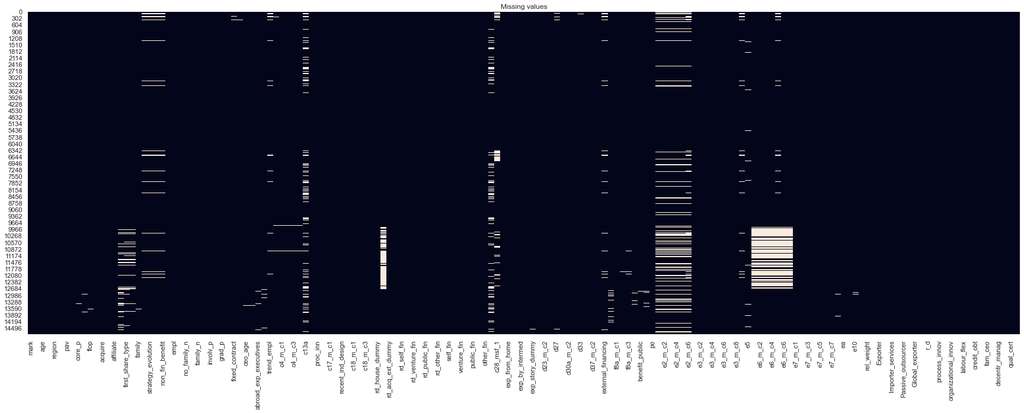

```python
print(df.shape)

plt.figure(figsize=(30,10))
sns.heatmap(df.isna(), cbar=False)
plt.title('Missing values')
plt.show()
```

# Dataset analysis

Before continuing on the treatment of missing values, we wanted to check our dataset

#### Analysis by country

The dataset contains information about firm in Europe, specifically 7 countries including France, Italy and Germany on the top 3.

```python
#Number of firms by country

pd.DataFrame(df['country'].value_counts()).reset_index()
```

|  | index | country |
| --- | --- | --- |
| 0 | ITA | 3021 |
| 1 | FRA | 2973 |
| 2 | GER | 2935 |
| 3 | SPA | 2832 |
| 4 | UK | 2067 |
| 5 | HUN | 488 |
| 6 | AUT | 443 |

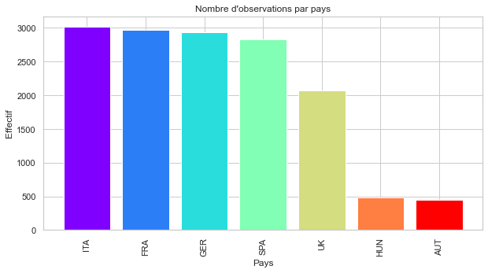

```python
import matplotlib.cm as cm

plt.figure(figsize = (10,5))
categorie = pd.DataFrame(df['country'].value_counts()).reset_index()['index']
effectif = pd.DataFrame(df['country'].value_counts()).reset_index()['country']
plt.title("Nombre d'observations par pays")
plt.xlabel("Pays")
plt.ylabel("Effectif")
plt.xticks(rotation = '90')
plt.bar(categorie, effectif, color = cm.rainbow(np.linspace(0,1, len(categorie))))
plt.show()
```

#### Type of firm

Almost half of companies are traditional industries, a quarter concerns economies of scale industries and the other are specialized or high-tech, we don't have information of this type on 684 observations.

```python
temp = pd.DataFrame(df['pavitt'].value_counts()).reset_index()
temp
```

|  | index | pavitt |
| --- | --- | --- |
| 0 | Traditional industries | 7037 |
| 1 | Economies of scale industries | 3725 |
| 2 | Specialized industries | 2665 |
| 3 | no available | 684 |
| 4 | High-tech industries | 648 |

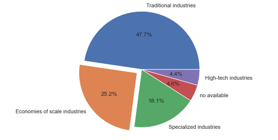

```python
plt.figure(figsize = (10,5))
explode = (0, 0.1, 0, 0, 0)
plt.pie(temp['pavitt'], labels = temp['index'], normalize = True, autopct='%1.1f%%',
        explode = explode)
plt.axis('equal')
plt.show()
```

```python
table = pd.pivot_table(df, values = 'mark', index = ['country'], columns=['pavitt'],  aggfunc='count')
table
```

| pavitt country | Economies of scale industries | High-tech industries | Specialized industries | Traditional industries | no available |
| --- | --- | --- | --- | --- | --- |
| AUT | 105 | 23 | 66 | 140 | 109 |
| FRA | 757 | 118 | 474 | 1364 | 260 |
| GER | 691 | 196 | 741 | 1230 | 77 |
| HUN | 133 | 15 | 106 | 226 | 8 |
| ITA | 752 | 101 | 519 | 1550 | 99 |
| SPA | 578 | 96 | 436 | 1636 | 86 |
| UK | 709 | 99 | 323 | 891 | 45 |

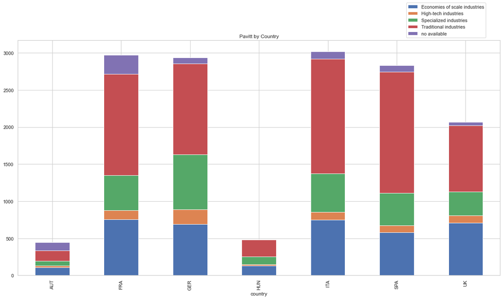

```python
table = pd.pivot_table(df, values = 'mark', index = ['country'], columns=['pavitt'],  aggfunc='count')

table.plot(kind="bar",stacked=True,figsize=(20,10))
plt.legend(loc="lower left",bbox_to_anchor=(0.8,1.0))
plt.title('Pavitt by Country')
plt.show()
```

#### Age

We have 2 variables giving information about the age of the company ("age" and "year"). But they don't match, we have decided to focus on the first one. We notice that most of the coompanies are very old (were created more than 20 years before).

```python
df['age'].value_counts()
```

```
More than 20 yrs        8522
Between 20 and 6 yrs    5194
Less than 6 yrs         1043
Name: age, dtype: int64
```

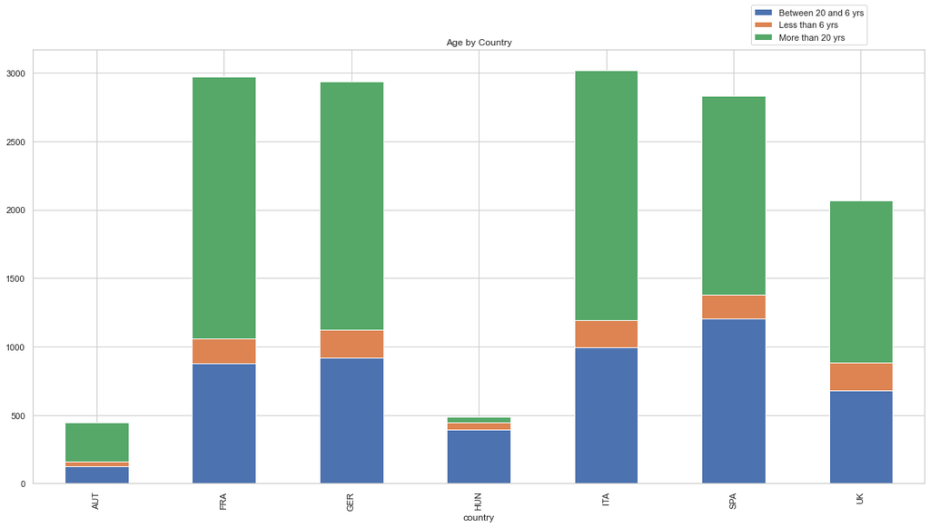

```python
table = pd.pivot_table(df, values = 'mark', index = ['country'], columns=['age'],  aggfunc='count')

table.plot(kind="bar",stacked=True,figsize=(20,10))
plt.legend(loc="lower left",bbox_to_anchor=(0.8,1.0))
plt.title('Age by Country')
plt.show()
```

#### Other variables

We try search on internet if there were any documentation about this dataset but sadly we couldn't find anything so we try to explore statistically the other variables to understand their meanings but we couldn't improve our analysis so we just keep wotking on missing values and the clustering.

```python
df['eb']
```

```
0        100.0
1        100.0
2        100.0
3         90.0
4        100.0
         ...
14754     98.0
14755     85.0
14756     90.0
14757     90.0
14758    100.0
Name: eb, Length: 14759, dtype: float64
```

```python
df['family'].value_counts()
```

```
1.000000e+00    10365
0.000000e+00     4362
1.000000e+10       19
Name: family, dtype: int64
```

We can see here that it is in fact a binary variable (0 or 1) which has been incorrectly re-signed

```python
df.groupby(['pavitt']).agg({'first_share' : 'mean'})
```

| pavitt | first_share |
| --- | --- |
| Economies of scale industries | 6.779668e+07 |
| High-tech industries | 1.286174e+08 |
| Specialized industries | 8.120657e+07 |
| Traditional industries | 6.822908e+07 |
| no available | 6.015044e+07 |

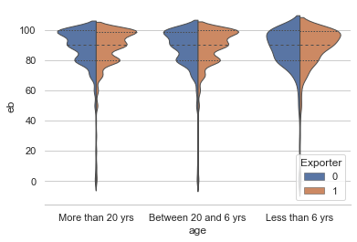

```python
sns.set_theme(style="whitegrid")
sns.violinplot(data=df, x="age", y="eb", hue="Exporter",
split=True, inner="quart", linewidth=1)
sns.despine(left=True)
```

### Filling missing data with mean observation

We could not delete all the columns with missing values, or we won't remain with a very interesting dataset. So, for the remaining missing values, we will fill them with the mean value. Of course, this doesn't work with categorical values, but we are lucky, we don't have any missing values in the categorical variables.

Isolating numerical variables by using the types, here we choose to select features with float type. As we fear that some integer type can be actually categorical (for example region).

```python
quanti = df.select_dtypes('float')
```

```python
quanti_col = quanti.columns
quanti_col
```

```
Index(['core_p', 'turnov', 'flop', 'acquire', 'affiliate', 'first_share',
       'first_share_type', 'first_share_naz', 'family', 'strategy',
       ...
       'e7_m_c5', 'e7_m_c6', 'e7_m_c7', 'e8', 'ea', 'eb', 'e10', 'e15',
       'rel_weight', 'abs_weight'],
      dtype='object', length=115)
```

```python
quali = df.drop(columns=quanti_col)
```

```python
quali.head()
```

|  | mark | pavitt | age | country | region | sector | pav | years | group | acquired | no_rewards | empl | rd_self_fin | rd_intra_group_fin | rd_venture_fin | rd_bank_fin | rd_public_fin | rd_leasing_fin | rd_other_fin | self_fin | intra_group_fin | venture_fin | bank_fin | public_fin | leasing_fin | other_fin | f8a_m_c1 | Exporter | Importer_materials | … |
| --- | --- | --- | --- | --- | --- | --- | --- | --- | --- | --- | --- | --- | --- | --- | --- | --- | --- | --- | --- | --- | --- | --- | --- | --- | --- | --- | --- | --- | --- | --- |
| 0 | 40 | Specialized industries | More than 20 yrs | AUT | 122 | 11 | 2 | 3 | 2 | 4 | 1 | 500 | 50 | 50 | 0 | 0 | 0 | 0 | 0 | 50 | 50 | 0 | 0 | 0 | 0 | 0 | 0 | 1 | 1 | … |
| 1 | 41 | Traditional industries | More than 20 yrs | AUT | 122 | 4 | 1 | 3 | 3 | 4 | 0 | 500 | 9999999999 | 9999999999 | 9999999999 | 9999999999 | 9999999999 | 9999999999 | 9999999999 | 9999999999 | 9999999999 | 9999999999 | 9999999999 | 9999999999 | 9999999999 | 9999999999 | 1 | 1 | 1 | … |
| 2 | 42 | Economies of scale industries | More than 20 yrs | AUT | 116 | 10 | 3 | 3 | 2 | 4 | 0 | 500 | 100 | 0 | 0 | 0 | 0 | 0 | 0 | 60 | 0 | 0 | 40 | 0 | 0 | 0 | 0 | 1 | 1 | … |
| 3 | 43 | Traditional industries | Between 20 and 6 yrs | AUT | 122 | 1 | 1 | 2 | 3 | 4 | 1 | 30 | 100 | 0 | 0 | 0 | 0 | 0 | 0 | 100 | 0 | 0 | 0 | 0 | 0 | 0 | 1 | 1 | 0 | … |
| 4 | 44 | Traditional industries | More than 20 yrs | AUT | 122 | 4 | 1 | 3 | 3 | 4 | 0 | 18 | 40 | 0 | 0 | 40 | 0 | 20 | 0 | 40 | 0 | 0 | 40 | 0 | 20 | 0 | 1 | 1 | 1 | … |

We checked manually if there were categorical variables with many different values, to treat them as numericals.

```python
quali.nunique()
```

```
mark                    14759
pavitt                      5
age                         3
country                     7
region                    166
sector                     11
pav                         5
years                       3
group                       3
acquired                    4
no_rewards                  2
empl                      354
rd_self_fin                59
rd_intra_group_fin         33
rd_venture_fin             24
rd_bank_fin                55
rd_public_fin              39
rd_leasing_fin             43
rd_other_fin               31
self_fin                   77
intra_group_fin            40
venture_fin                34
bank_fin                   85
public_fin                 45
leasing_fin                67
other_fin                  47
f8a_m_c1                    2
Exporter                    2
Importer_materials          2
Importer_services           2
Active_outsourcer           2
Passive_outsourcer          2
FDI                         2
Global_exporter             2
Active_abroad               2
r_d                         2
product_innov               2
process_innov               2
mkt_innov                   2
organizational_innov        2
hk                          2
labour_flex                 2
credit_req                  2
credit_obt                  2
fam_managed                 2
fam_ceo                     2
for_group                   2
decentr_manag               2
bonus.1                     2
qual_cert                   2
comp                        2
dtype: int64
```

We delete some variables like mark, which is just an identification code for the firm and region which will not bring any further information. Other are quantitative, so we are adding them in the quantitative dataframe (empl, ...).

```python
quanti2 = df[['empl','rd_self_fin','rd_intra_group_fin','rd_venture_fin','rd_bank_fin','rd_public_fin',
                    'rd_leasing_fin','rd_other_fin','self_fin','intra_group_fin','venture_fin','bank_fin','public_fin','leasing_fin','other_fin']]
```

```python
quali = quali.drop(columns=['mark','region','empl','rd_self_fin','rd_intra_group_fin','rd_venture_fin','rd_bank_fin','rd_public_fin',
                    'rd_leasing_fin','rd_other_fin','self_fin','intra_group_fin','venture_fin','bank_fin','public_fin','leasing_fin','other_fin'])
```

```python
quanti = pd.concat([quanti,quanti2],axis=1)
quanti.head()
```

|  | core_p | turnov | flop | acquire | affiliate | first_share | first_share_type | first_share_naz | family | strategy | strategy_evolution | fin_benefit | non_fin_benefit | no_family_p | no_family_n | family_p | family_n | family_tmt | involv_p | involv_n | grad_p | grad_n | fixed_contract | part_time | ceo_age | ceo_gender | abroad_exp_executives | training | trend_empl | … |
| --- | --- | --- | --- | --- | --- | --- | --- | --- | --- | --- | --- | --- | --- | --- | --- | --- | --- | --- | --- | --- | --- | --- | --- | --- | --- | --- | --- | --- | --- | --- |
| 0 | 100.0 | 7.0 | 2.0 | 2.0 | 2.0 | 100.0 | 6.0 | 2.0 | 1.0 | 2.0 | 3.0 | 0.0 | 0.0 | 5.000000 | 25.0 | 0.000000 | 0.0 | 0.000000e+00 | 40.000000 | 200.0 | 7.000000 | 35.0 | 0.000000e+00 | 5.000000e+00 | 4.0 | 1.0 | 1.0 | 1.000000e+10 | 1.0 | … |
| 1 | 100.0 | 6.0 | 1.0 | 4.0 | 2.0 | 100.0 | 2.0 | 1.0 | 1.0 | 2.0 | 3.0 | 1.0 | 0.0 | 0.000000 | 0.0 | 0.000000 | 0.0 | 1.000000e+10 | 2.000000 | 10.0 | 2.000000 | 10.0 | 1.000000e+10 | 1.000000e+10 | 4.0 | 1.0 | 1.0 | 5.000000e+00 | 3.0 | … |
| 2 | 100.0 | 6.0 | 2.0 | 2.0 | 4.0 | 100.0 | NaN | 1.0 | 1.0 | NaN | NaN | NaN | NaN | 7.600000 | 38.0 | 0.400000 | 2.0 | 5.000000e+00 | 6.000000 | 30.0 | 6.000000 | 30.0 | 1.500000e+01 | 1.500000e+01 | 4.0 | 1.0 | 1.0 | 1.000000e+01 | 1.0 | … |
| 3 | 100.0 | 3.0 | 2.0 | 4.0 | 4.0 | 38.0 | 1.0 | 1.0 | 1.0 | 1.0 | 3.0 | 0.0 | 0.0 | 13.333333 | 4.0 | 6.666667 | 2.0 | 3.333333e+01 | 3.333333 | 1.0 | 6.666667 | 2.0 | 0.000000e+00 | 4.000000e+00 | 4.0 | 1.0 | 1.0 | 1.000000e+00 | 3.0 | … |
| 4 | 95.0 | 2.0 | 2.0 | 4.0 | 4.0 | 100.0 | 1.0 | 1.0 | 1.0 | 1.0 | 3.0 | 1.0 | 0.0 | 22.222222 | 4.0 | 16.666667 | 3.0 | 4.285714e+01 | 0.000000 | 0.0 | 5.555556 | 1.0 | 0.000000e+00 | 2.000000e+01 | 5.0 | 1.0 | 1.0 | 0.000000e+00 | 1.0 | … |

We are using a standard method to fill these missing values, we could have use the median but as we are not convinced by replacing our missing values by the mean or even the median, we did not want to lose time on this.

```python
from sklearn.impute import SimpleImputer
imp_mean = SimpleImputer(missing_values=np.nan, strategy='mean')
imp_mean.fit(quanti)
iquanti = pd.DataFrame(imp_mean.transform(quanti))
iquanti.columns = quanti.columns
iquanti.index = quanti.index
```

```python
iquanti.head()
```

|  | core_p | turnov | flop | acquire | affiliate | first_share | first_share_type | first_share_naz | family | strategy | strategy_evolution | fin_benefit | non_fin_benefit | no_family_p | no_family_n | family_p | family_n | family_tmt | involv_p | involv_n | grad_p | grad_n | fixed_contract | part_time | ceo_age | ceo_gender | abroad_exp_executives | training | trend_empl | … |
| --- | --- | --- | --- | --- | --- | --- | --- | --- | --- | --- | --- | --- | --- | --- | --- | --- | --- | --- | --- | --- | --- | --- | --- | --- | --- | --- | --- | --- | --- | --- |
| 0 | 100.0 | 7.0 | 2.0 | 2.0 | 2.0 | 100.0 | 6.000000e+00 | 2.0 | 1.0 | 2.000000 | 3.000000e+00 | 0.000000 | 0.000000 | 5.000000 | 25.0 | 0.000000 | 0.0 | 0.000000e+00 | 40.000000 | 200.0 | 7.000000 | 35.0 | 0.000000e+00 | 5.000000e+00 | 4.0 | 1.0 | 1.0 | 1.000000e+10 | 1.0 | … |
| 1 | 100.0 | 6.0 | 1.0 | 4.0 | 2.0 | 100.0 | 2.000000e+00 | 1.0 | 1.0 | 2.000000 | 3.000000e+00 | 1.000000 | 0.000000 | 0.000000 | 0.0 | 0.000000 | 0.0 | 1.000000e+10 | 2.000000 | 10.0 | 2.000000 | 10.0 | 1.000000e+10 | 1.000000e+10 | 4.0 | 1.0 | 1.0 | 5.000000e+00 | 3.0 | … |
| 2 | 100.0 | 6.0 | 2.0 | 2.0 | 4.0 | 100.0 | 3.636364e+07 | 1.0 | 1.0 | 1.291002 | 1.405385e+06 | 0.347334 | 0.059071 | 7.600000 | 38.0 | 0.400000 | 2.0 | 5.000000e+00 | 6.000000 | 30.0 | 6.000000 | 30.0 | 1.500000e+01 | 1.500000e+01 | 4.0 | 1.0 | 1.0 | 1.000000e+01 | 1.0 | … |
| 3 | 100.0 | 3.0 | 2.0 | 4.0 | 4.0 | 38.0 | 1.000000e+00 | 1.0 | 1.0 | 1.000000 | 3.000000e+00 | 0.000000 | 0.000000 | 13.333333 | 4.0 | 6.666667 | 2.0 | 3.333333e+01 | 3.333333 | 1.0 | 6.666667 | 2.0 | 0.000000e+00 | 4.000000e+00 | 4.0 | 1.0 | 1.0 | 1.000000e+00 | 3.0 | … |
| 4 | 95.0 | 2.0 | 2.0 | 4.0 | 4.0 | 100.0 | 1.000000e+00 | 1.0 | 1.0 | 1.000000 | 3.000000e+00 | 1.000000 | 0.000000 | 22.222222 | 4.0 | 16.666667 | 3.0 | 4.285714e+01 | 0.000000 | 0.0 | 5.555556 | 1.0 | 0.000000e+00 | 2.000000e+01 | 5.0 | 1.0 | 1.0 | 0.000000e+00 | 1.0 | … |

```python
# Checking missing values in qualitative data
(quali.isnull().sum())/(quali.shape[0])
```

```
pavitt                  0.0
age                     0.0
country                 0.0
sector                  0.0
pav                     0.0
years                   0.0
group                   0.0
acquired                0.0
no_rewards              0.0
f8a_m_c1                0.0
Exporter                0.0
Importer_materials      0.0
Importer_services       0.0
Active_outsourcer       0.0
Passive_outsourcer      0.0
FDI                     0.0
Global_exporter         0.0
Active_abroad           0.0
r_d                     0.0
product_innov           0.0
process_innov           0.0
mkt_innov               0.0
organizational_innov    0.0
hk                      0.0
labour_flex             0.0
credit_req              0.0
credit_obt              0.0
fam_managed             0.0
fam_ceo                 0.0
for_group               0.0
decentr_manag           0.0
bonus.1                 0.0
qual_cert               0.0
comp                    0.0
dtype: float64
```

```python
df_famd = pd.concat([quali,iquanti], axis=1)
```

# FAMD

As our dataset has mix type of features and as we want to reduce the dimensionality, we instinctively tried an FAMD (Factor Analysis of Mixed Data). The result is not very interesting, as we can't really distinguish clusters. We reduce on two components and they explain less than 10% of the variance. We suppose that our method of dealing with missing values didn't work well.

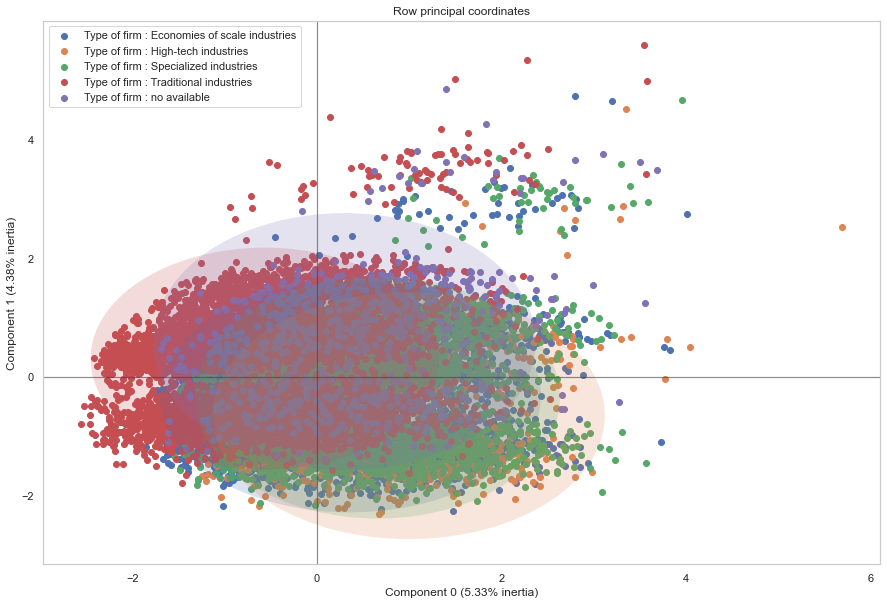

```python
from prince import FAMD
famd = FAMD(n_components =2, n_iter = 3, random_state = 101)

famd.fit(df_famd)
famd.transform(df_famd)
famd.plot_row_coordinates(df_famd,figsize=(15, 10),color_labels=['Type of firm : {}'.format(t) for t in df_famd['pavitt']] ) ;
```

### Filling missing data with KNN method

Instead of simply filling missing data with mean or median, we thought that looking for 3 nearest neighbors of each missing value can be a better strategy. As we will see, it was quite a deception, maybe we deleted too much columns for our dataset initially.

```python
from sklearn.impute import KNNImputer

imputer = KNNImputer(n_neighbors=3)
knn_quanti = pd.DataFrame(imputer.fit_transform(quanti))
knn_quanti.columns = quanti.columns
knn_quanti.index = quanti.index
```

```python
knn_quanti.head()
```

|  | core_p | turnov | flop | acquire | affiliate | first_share | first_share_type | first_share_naz | family | strategy | strategy_evolution | fin_benefit | non_fin_benefit | no_family_p | no_family_n | family_p | family_n | family_tmt | involv_p | involv_n | grad_p | grad_n | fixed_contract | part_time | ceo_age | ceo_gender | abroad_exp_executives | training | trend_empl | … |
| --- | --- | --- | --- | --- | --- | --- | --- | --- | --- | --- | --- | --- | --- | --- | --- | --- | --- | --- | --- | --- | --- | --- | --- | --- | --- | --- | --- | --- | --- | --- |
| 0 | 100.0 | 7.0 | 2.0 | 2.0 | 2.0 | 100.0 | 6.000000e+00 | 2.0 | 1.0 | 2.0 | 3.0 | 0.000000 | 0.0 | 5.000000 | 25.0 | 0.000000 | 0.0 | 0.000000e+00 | 40.000000 | 200.0 | 7.000000 | 35.0 | 0.000000e+00 | 5.000000e+00 | 4.0 | 1.0 | 1.0 | 1.000000e+10 | 1.0 | … |
| 1 | 100.0 | 6.0 | 1.0 | 4.0 | 2.0 | 100.0 | 2.000000e+00 | 1.0 | 1.0 | 2.0 | 3.0 | 1.000000 | 0.0 | 0.000000 | 0.0 | 0.000000 | 0.0 | 1.000000e+10 | 2.000000 | 10.0 | 2.000000 | 10.0 | 1.000000e+10 | 1.000000e+10 | 4.0 | 1.0 | 1.0 | 5.000000e+00 | 3.0 | … |
| 2 | 100.0 | 6.0 | 2.0 | 2.0 | 4.0 | 100.0 | 3.333333e+09 | 1.0 | 1.0 | 1.0 | 3.0 | 0.333333 | 0.0 | 7.600000 | 38.0 | 0.400000 | 2.0 | 5.000000e+00 | 6.000000 | 30.0 | 6.000000 | 30.0 | 1.500000e+01 | 1.500000e+01 | 4.0 | 1.0 | 1.0 | 1.000000e+01 | 1.0 | … |
| 3 | 100.0 | 3.0 | 2.0 | 4.0 | 4.0 | 38.0 | 1.000000e+00 | 1.0 | 1.0 | 1.0 | 3.0 | 0.000000 | 0.0 | 13.333333 | 4.0 | 6.666667 | 2.0 | 3.333333e+01 | 3.333333 | 1.0 | 6.666667 | 2.0 | 0.000000e+00 | 4.000000e+00 | 4.0 | 1.0 | 1.0 | 1.000000e+00 | 3.0 | … |
| 4 | 95.0 | 2.0 | 2.0 | 4.0 | 4.0 | 100.0 | 1.000000e+00 | 1.0 | 1.0 | 1.0 | 3.0 | 1.000000 | 0.0 | 22.222222 | 4.0 | 16.666667 | 3.0 | 4.285714e+01 | 0.000000 | 0.0 | 5.555556 | 1.0 | 0.000000e+00 | 2.000000e+01 | 5.0 | 1.0 | 1.0 | 0.000000e+00 | 1.0 | … |

```python
df_famd2 = pd.concat([quali,knn_quanti], axis=1)
```

### FAMD with KNN method of filling missing values

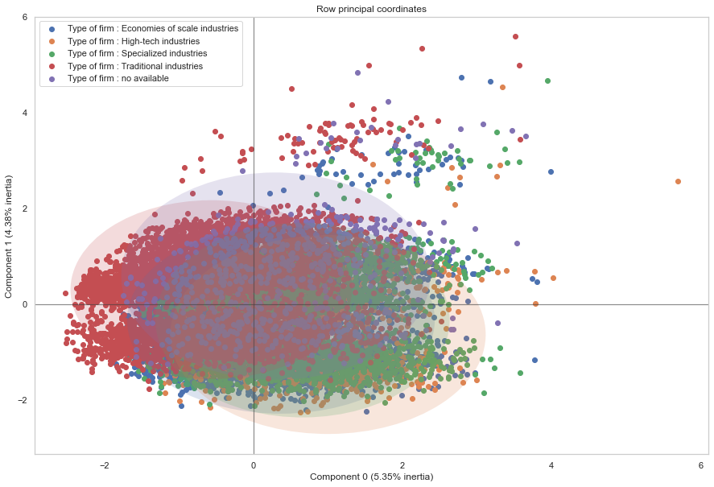

```python
famd2 = FAMD(n_components =2, n_iter = 3, random_state = 101)

famd = famd2.fit_transform(df_famd2)
famd2.plot_row_coordinates(df_famd2,figsize=(15, 10),color_labels=['Type of firm : {}'.format(t) for t in df_famd2['pavitt']] ) ;
```

We still try to reperesent the graphic in 3d, if by chance there were clusters we could not see in 2d.

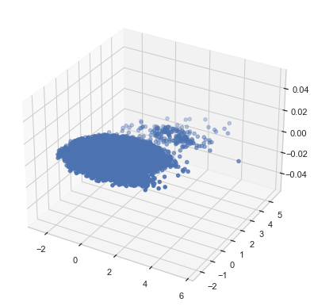

```python
fig = plt.figure(figsize=(15, 15))
ax1 = fig.add_subplot(221, projection='3d')
ax1.scatter(famd.loc[:, 0], famd.loc[:, 1]) ;
```

## Trying PCA by transforming variables

We wanted to try a last thing : reducing dimension with PCA by transforming qualitative variables in dummies.

One hot encoder for qualitative data

```python
df_dummies = pd.get_dummies(quali, columns=['pavitt','age','country','pav','sector','years','group','acquired'])
df_dummies.head()
```

|  | no_rewards | f8a_m_c1 | Exporter | Importer_materials | Importer_services | Active_outsourcer | Passive_outsourcer | FDI | Global_exporter | Active_abroad | r_d | product_innov | process_innov | mkt_innov | organizational_innov | hk | labour_flex | credit_req | credit_obt | fam_managed | fam_ceo | for_group | decentr_manag | bonus.1 | qual_cert | comp | pavitt_Economies of scale industries | pavitt_High-tech industries | pavitt_Specialized industries | … |
| --- | --- | --- | --- | --- | --- | --- | --- | --- | --- | --- | --- | --- | --- | --- | --- | --- | --- | --- | --- | --- | --- | --- | --- | --- | --- | --- | --- | --- | --- | --- |
| 0 | 1 | 0 | 1 | 1 | 1 | 0 | 1 | 1 | 1 | 1 | 1 | 1 | 1 | 1 | 1 | 0 | 1 | 0 | 0 | 0 | 0 | 1 | 1 | 0 | 1 | 1 | 0 | 0 | 1 | … |
| 1 | 0 | 1 | 1 | 1 | 1 | 0 | 1 | 1 | 1 | 1 | 1 | 0 | 1 | 0 | 1 | 0 | 0 | 0 | 0 | 0 | 1 | 0 | 1 | 1 | 1 | 1 | 0 | 0 | 0 | … |
| 2 | 0 | 0 | 1 | 1 | 1 | 0 | 0 | 1 | 1 | 1 | 1 | 1 | 0 | 1 | 0 | 1 | 1 | 1 | 1 | 0 | 1 | 1 | 0 | 0 | 1 | 1 | 1 | 0 | 0 | … |
| 3 | 1 | 1 | 1 | 0 | 0 | 0 | 0 | 0 | 0 | 1 | 1 | 1 | 0 | 1 | 1 | 1 | 1 | 0 | 0 | 0 | 1 | 0 | 0 | 0 | 0 | 0 | 0 | 0 | 0 | … |
| 4 | 0 | 1 | 1 | 1 | 1 | 1 | 1 | 0 | 1 | 1 | 0 | 1 | 0 | 1 | 1 | 1 | 1 | 0 | 0 | 1 | 1 | 0 | 0 | 1 | 0 | 1 | 0 | 0 | 0 | … |

Qualitative data has to be centered

```python
for i in range(67):
    df_dummies.iloc[:,i]=df_dummies.iloc[:,i]/(np.sqrt(sum(df_dummies.iloc[:,i])/len(df_dummies)))
df_dummies.head()
```

|  | no_rewards | f8a_m_c1 | Exporter | Importer_materials | Importer_services | Active_outsourcer | Passive_outsourcer | FDI | Global_exporter | Active_abroad | r_d | product_innov | process_innov | mkt_innov | organizational_innov | hk | labour_flex | credit_req | credit_obt | fam_managed | fam_ceo | for_group | decentr_manag | bonus.1 | qual_cert | comp | pavitt_Economies of scale industries | pavitt_High-tech industries | pavitt_Specialized industries | … |
| --- | --- | --- | --- | --- | --- | --- | --- | --- | --- | --- | --- | --- | --- | --- | --- | --- | --- | --- | --- | --- | --- | --- | --- | --- | --- | --- | --- | --- | --- | --- |
| 0 | 1.275279 | 0.000000 | 1.224144 | 1.422088 | 2.068625 | 0.000000 | 1.595335 | 4.530687 | 1.917042 | 1.139978 | 1.292118 | 1.42728 | 1.507668 | 1.781758 | 1.773764 | 0.000000 | 1.107863 | 0.000000 | 0.00000 | 0.000000 | 0.000000 | 3.368138 | 1.887431 | 0.000000 | 1.296083 | 1.382764 | 0.000000 | 0.0 | 2.353314 | … |
| 1 | 0.000000 | 1.274296 | 1.224144 | 1.422088 | 2.068625 | 0.000000 | 1.595335 | 4.530687 | 1.917042 | 1.139978 | 1.292118 | 0.00000 | 1.507668 | 0.000000 | 1.773764 | 0.000000 | 0.000000 | 0.000000 | 0.00000 | 0.000000 | 1.268379 | 0.000000 | 1.887431 | 1.651542 | 1.296083 | 1.382764 | 0.000000 | 0.0 | 0.000000 | … |
| 2 | 0.000000 | 0.000000 | 1.224144 | 1.422088 | 2.068625 | 0.000000 | 0.000000 | 4.530687 | 1.917042 | 1.139978 | 1.292118 | 1.42728 | 0.000000 | 1.781758 | 0.000000 | 1.899853 | 1.107863 | 2.718563 | 3.23878 | 0.000000 | 1.268379 | 3.368138 | 0.000000 | 0.000000 | 1.296083 | 1.382764 | 1.990514 | 0.0 | 0.000000 | … |
| 3 | 1.275279 | 1.274296 | 1.224144 | 0.000000 | 0.000000 | 0.000000 | 0.000000 | 0.000000 | 0.000000 | 1.139978 | 1.292118 | 1.42728 | 0.000000 | 1.781758 | 1.773764 | 1.899853 | 1.107863 | 0.000000 | 0.00000 | 0.000000 | 1.268379 | 0.000000 | 0.000000 | 0.000000 | 0.000000 | 0.000000 | 0.000000 | 0.0 | 0.000000 | … |
| 4 | 0.000000 | 1.274296 | 1.224144 | 1.422088 | 2.068625 | 5.001525 | 1.595335 | 0.000000 | 1.917042 | 1.139978 | 0.000000 | 1.42728 | 0.000000 | 1.781758 | 1.773764 | 1.899853 | 1.107863 | 0.000000 | 0.00000 | 2.006742 | 1.268379 | 0.000000 | 0.000000 | 1.651542 | 0.000000 | 1.382764 | 0.000000 | 0.0 | 0.000000 | … |

Quantitative variables have to be standardised

```python
from sklearn.preprocessing import StandardScaler

quant_scaled = pd.DataFrame(StandardScaler().fit_transform(iquanti),columns=iquanti.columns)
quant_scaled.head()
```

|  | core_p | turnov | flop | acquire | affiliate | first_share | first_share_type | first_share_naz | family | strategy | strategy_evolution | fin_benefit | non_fin_benefit | no_family_p | no_family_n | family_p | family_n | family_tmt | involv_p | involv_n | grad_p | grad_n | fixed_contract | part_time | ceo_age | ceo_gender | abroad_exp_executives | training | trend_empl | … |
| --- | --- | --- | --- | --- | --- | --- | --- | --- | --- | --- | --- | --- | --- | --- | --- | --- | --- | --- | --- | --- | --- | --- | --- | --- | --- | --- | --- | --- | --- | --- |
| 0 | -0.053523 | -0.082379 | -0.512275 | -0.011646 | -0.008236 | -0.087422 | -6.137410e-02 | -0.04874 | -0.035934 | 1.589254 | -1.207365e-02 | -0.742759 | -0.255111 | -0.042009 | -0.042009 | -0.040358 | -0.040358 | -0.206746 | -0.008231 | -0.008229 | -0.010769 | -0.009325 | -0.059734 | -0.048895 | -0.036932 | -0.016482 | -0.081212 | 9.868506 | -1.018981 | … |
| 1 | -0.053523 | -0.082379 | -1.426085 | -0.011646 | -0.008236 | -0.087422 | -6.137410e-02 | -0.04874 | -0.035934 | 1.589254 | -1.207365e-02 | 1.395695 | -0.255111 | -0.042009 | -0.042009 | -0.040358 | -0.040358 | 4.836842 | -0.008232 | -0.008232 | -0.011024 | -0.011473 | 16.817323 | 20.510555 | -0.036932 | -0.016482 | -0.081212 | -0.101933 | 1.161249 | … |
| 2 | -0.053523 | -0.082379 | -0.512275 | -0.011646 | -0.008236 | -0.087422 | -1.257500e-17 | -0.04874 | -0.035934 | 0.000000 | -2.000249e-18 | 0.000000 | 0.000000 | -0.042009 | -0.042009 | -0.040358 | -0.040358 | -0.206746 | -0.008232 | -0.008231 | -0.010820 | -0.009754 | -0.059734 | -0.048895 | -0.036932 | -0.016482 | -0.081212 | -0.101933 | -1.018981 | … |
| 3 | -0.053523 | -0.082379 | -0.512275 | -0.011646 | -0.008236 | -0.087423 | -6.137411e-02 | -0.04874 | -0.035934 | -0.652296 | -1.207365e-02 | -0.742759 | -0.255111 | -0.042009 | -0.042009 | -0.040358 | -0.040358 | -0.206746 | -0.008232 | -0.008232 | -0.010786 | -0.012160 | -0.059734 | -0.048895 | -0.036932 | -0.016482 | -0.081212 | -0.101933 | 1.161249 | … |
| 4 | -0.053523 | -0.082379 | -0.512275 | -0.011646 | -0.008236 | -0.087422 | -6.137411e-02 | -0.04874 | -0.035934 | -0.652296 | -1.207365e-02 | 1.395695 | -0.255111 | -0.042009 | -0.042009 | -0.040358 | -0.040358 | -0.206746 | -0.008232 | -0.008232 | -0.010843 | -0.012246 | -0.059734 | -0.048894 | -0.036932 | -0.016482 | -0.081212 | -0.101933 | -1.018981 | … |

```python
#concatenation of qualitative and continuous variables

df_pca = pd.concat([df_dummies,quant_scaled], axis=1)
df_pca.head()
```

|  | no_rewards | f8a_m_c1 | Exporter | Importer_materials | Importer_services | Active_outsourcer | Passive_outsourcer | FDI | Global_exporter | Active_abroad | r_d | product_innov | process_innov | mkt_innov | organizational_innov | hk | labour_flex | credit_req | credit_obt | fam_managed | fam_ceo | for_group | decentr_manag | bonus.1 | qual_cert | comp | pavitt_Economies of scale industries | pavitt_High-tech industries | pavitt_Specialized industries | … |
| --- | --- | --- | --- | --- | --- | --- | --- | --- | --- | --- | --- | --- | --- | --- | --- | --- | --- | --- | --- | --- | --- | --- | --- | --- | --- | --- | --- | --- | --- | --- |
| 0 | 1.275279 | 0.000000 | 1.224144 | 1.422088 | 2.068625 | 0.000000 | 1.595335 | 4.530687 | 1.917042 | 1.139978 | 1.292118 | 1.42728 | 1.507668 | 1.781758 | 1.773764 | 0.000000 | 1.107863 | 0.000000 | 0.00000 | 0.000000 | 0.000000 | 3.368138 | 1.887431 | 0.000000 | 1.296083 | 1.382764 | 0.000000 | 0.0 | 2.353314 | … |
| 1 | 0.000000 | 1.274296 | 1.224144 | 1.422088 | 2.068625 | 0.000000 | 1.595335 | 4.530687 | 1.917042 | 1.139978 | 1.292118 | 0.00000 | 1.507668 | 0.000000 | 1.773764 | 0.000000 | 0.000000 | 0.000000 | 0.00000 | 0.000000 | 1.268379 | 0.000000 | 1.887431 | 1.651542 | 1.296083 | 1.382764 | 0.000000 | 0.0 | 0.000000 | … |
| 2 | 0.000000 | 0.000000 | 1.224144 | 1.422088 | 2.068625 | 0.000000 | 0.000000 | 4.530687 | 1.917042 | 1.139978 | 1.292118 | 1.42728 | 0.000000 | 1.781758 | 0.000000 | 1.899853 | 1.107863 | 2.718563 | 3.23878 | 0.000000 | 1.268379 | 3.368138 | 0.000000 | 0.000000 | 1.296083 | 1.382764 | 1.990514 | 0.0 | 0.000000 | … |
| 3 | 1.275279 | 1.274296 | 1.224144 | 0.000000 | 0.000000 | 0.000000 | 0.000000 | 0.000000 | 0.000000 | 1.139978 | 1.292118 | 1.42728 | 0.000000 | 1.781758 | 1.773764 | 1.899853 | 1.107863 | 0.000000 | 0.00000 | 0.000000 | 1.268379 | 0.000000 | 0.000000 | 0.000000 | 0.000000 | 0.000000 | 0.000000 | 0.0 | 0.000000 | … |
| 4 | 0.000000 | 1.274296 | 1.224144 | 1.422088 | 2.068625 | 5.001525 | 1.595335 | 0.000000 | 1.917042 | 1.139978 | 0.000000 | 1.42728 | 0.000000 | 1.781758 | 1.773764 | 1.899853 | 1.107863 | 0.000000 | 0.00000 | 2.006742 | 1.268379 | 0.000000 | 0.000000 | 1.651542 | 0.000000 | 1.382764 | 0.000000 | 0.0 | 0.000000 | … |

```python
from sklearn.decomposition import PCA

pca= PCA(n_components=2)
pcs = pca.fit_transform(df_pca)
pdf = pd.DataFrame(data = pcs, columns = ['PC1', 'PC2'])
```

```python
pca.explained_variance_ratio_
```

```
array([0.05347654, 0.04440927])
```

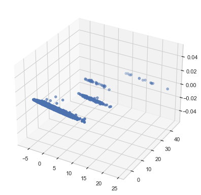

```python
fig = plt.figure(figsize=(15, 15))
ax1 = fig.add_subplot(221, projection='3d')
ax1.scatter(pcs[:, 0], pcs[:, 1],  cmap=plt.cm.Spectral) ;
```

```python
mappa= pd.DataFrame(pca.components_,columns=df_pca.columns)
```

```python
plotto = mappa.T
plotto = plotto.reset_index()
```

```python
def scatter_text(x, y, text_column, data, title, xlabel, ylabel):
    """Scatter plot with country codes on the x y coordinates
       Based on this answer: https://stackoverflow.com/a/54789170/2641825"""
    # Create the scatter plot
    p1 = sns.scatterplot(x, y, data=data, size = 8, legend=False)
    # Add text besides each point
    for line in range(0,data.shape[0]):
         p1.text(data[x][line]+0.01, data[y][line],
                 data[text_column][line], horizontalalignment='left',
                 size='large', color='black', weight='semibold')
    # Set title and axis labels
    plt.title(title)
    plt.xlabel(xlabel)
    plt.ylabel(ylabel)
    return p1
```

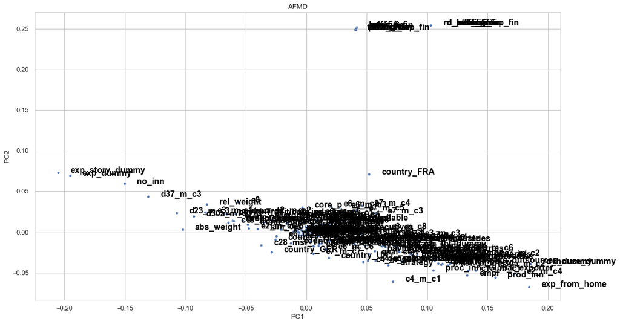

```python
plt.figure(figsize=(16,9))
scatter_text(0, 1,'index' ,
             data = plotto,
             title = 'AFMD',
             xlabel = 'PC1',
             ylabel = 'PC2');
```